## Correlatie slaapscore vs hartslag overdag

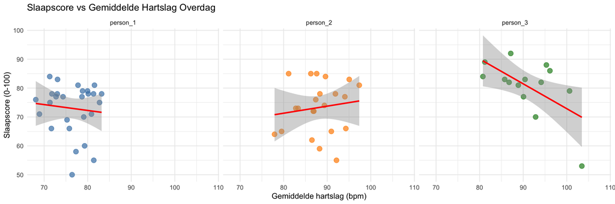

```r
ggplot(df_all, aes(x = average_heart_rate, y = sleep_score, color = naam)) +
  geom_point(size = 3, alpha = 0.7) +
  geom_smooth(method = "lm", color = "red", se = TRUE) +
  facet_wrap(~ naam) +
  scale_color_manual(values = c("person_1" = "steelblue", "person_2" = "darkorange", "person_3" = "forestgreen")) +
  scale_fill_manual(values = c("person_1" = "steelblue", "person_2" = "darkorange", "person_3" = "forestgreen")) +
  labs(title = "Slaapscore vs Gemiddelde Hartslag Overdag",
       x = "Gemiddelde hartslag (bpm)",
       y = "Slaapscore (0-100)") +
  theme_minimal() +
  theme(legend.position = "none")
```

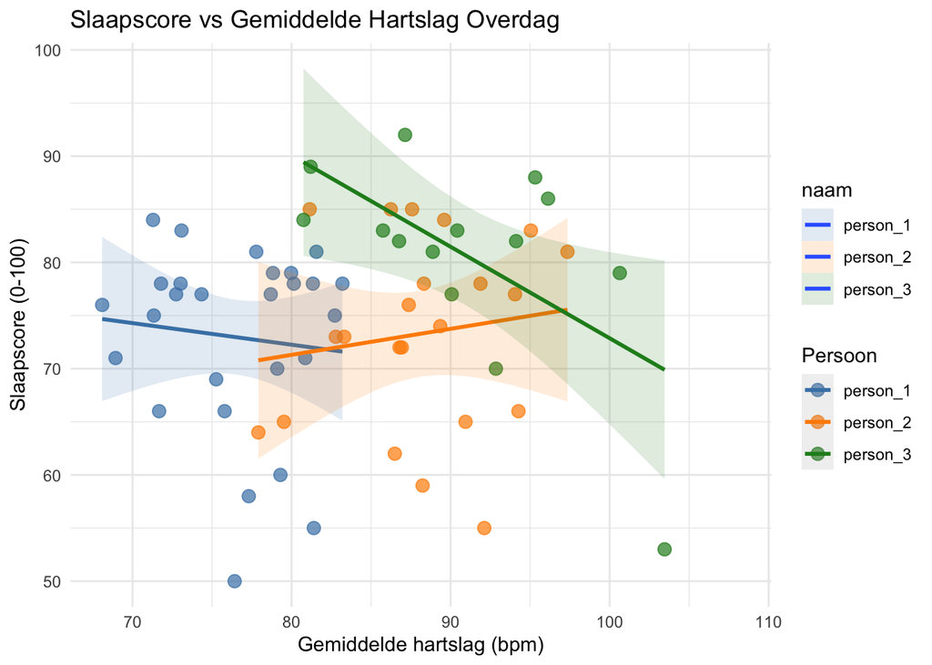

```r
ggplot(df_all, aes(x = average_heart_rate, y = sleep_score, color = naam)) +
  geom_point(size = 3, alpha = 0.7) +
  geom_smooth(method = "lm", aes(color = naam, fill = naam), se = TRUE, alpha = 0.15) +
  scale_color_manual(values = c("person_1" = "steelblue", "person_2" = "darkorange", "person_3" = "forestgreen")) +
  scale_fill_manual(values = c("person_1" = "steelblue", "person_2" = "darkorange", "person_3" = "forestgreen")) +
  labs(title = "Slaapscore vs Gemiddelde Hartslag Overdag",
       x = "Gemiddelde hartslag (bpm)",
       y = "Slaapscore (0-100)",
       color = "Persoon") +
  theme_minimal() +
  theme(legend.position = "right")
```

**Observatie:** De punten en regressielijnen tonen zwakke en inconsistente verbanden tussen gemiddelde hartslag en de slaapscore. Individuele grafieken laten verschillende richtingen en steilheden zien, en de gecombineerde plot toont veel overlap tussen personen.

Waarschijnlijk is de gemiddelde hartslag tijdens slaap een betere indicator voor slaapkwaliteit dan de slaapscore, gezien de onaccuraatheid van de slaapscore en de sterke invloed van slaapduur op die score. Vanwege de onbetrouwbaarheid van de slaapscore zal alleen de gemiddelde hartslag tijdens slaap als indicator voor slaapkwaliteit genomen wordenin plaats van de slaapscore.

## Correlatie gemiddelde hartslag slaap vs hartslag overdag

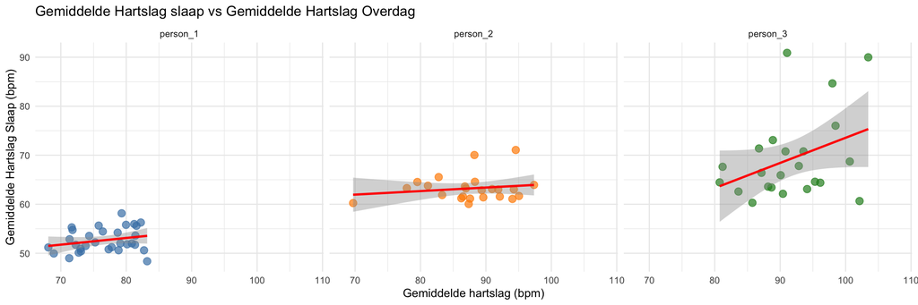

```r
ggplot(df_all, aes(x = average_heart_rate, y = average_sleep_heart_rate, color = naam)) +
  geom_point(size = 3, alpha = 0.7) +
  geom_smooth(method = "lm", color = "red", se = TRUE) +
  facet_wrap(~ naam) +
  scale_color_manual(values = c("person_1" = "steelblue", "person_2" = "darkorange", "person_3" = "forestgreen")) +
  scale_fill_manual(values = c("person_1" = "steelblue", "person_2" = "darkorange", "person_3" = "forestgreen")) +
  labs(title = "Gemiddelde Hartslag slaap vs Gemiddelde Hartslag Overdag",
       x = "Gemiddelde hartslag (bpm)",
       y = "Gemiddelde Hartslag Slaap (bpm)") +
  theme_minimal() +
  theme(legend.position = "none")
```

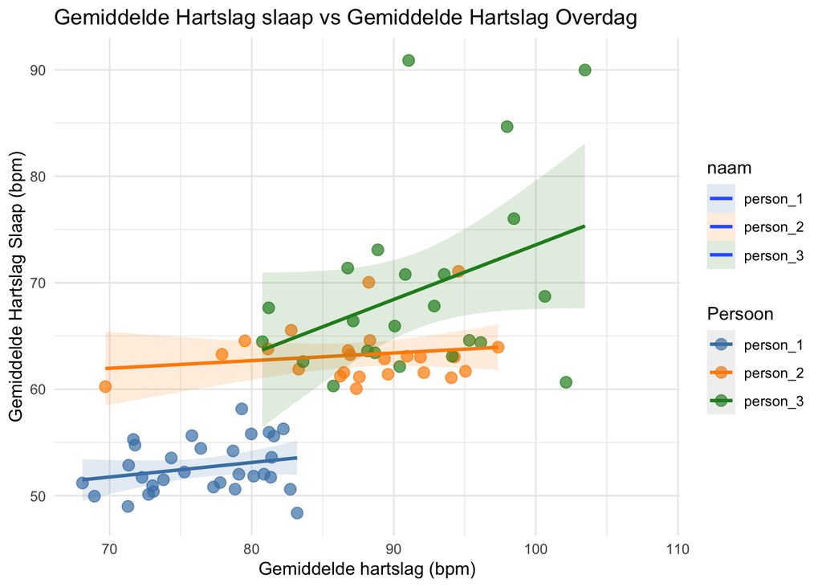

```r
ggplot(df_all, aes(x = average_heart_rate, y = average_sleep_heart_rate, color = naam)) +
  geom_point(size = 3, alpha = 0.7) +
  geom_smooth(method = "lm", aes(color = naam, fill = naam), se = TRUE, alpha = 0.15) +
  scale_color_manual(values = c("person_1" = "steelblue", "person_2" = "darkorange", "person_3" = "forestgreen")) +
  scale_fill_manual(values = c("person_1" = "steelblue", "person_2" = "darkorange", "person_3" = "forestgreen")) +
  labs(title = "Gemiddelde Hartslag slaap vs Gemiddelde Hartslag Overdag",
       x = "Gemiddelde hartslag (bpm)",
       y = "Gemiddelde Hartslag Slaap (bpm)",
       color = "Persoon") +
  theme_minimal() +
  theme(legend.position = "right")
```

**Observatie:** Voor de relatie tussen gemiddelde hartslag en hartslag tijdens slaap is over het algemeen een positieve samenhang: personen met hogere hartslag overdag hebben vaak ook hogere hartslag tijdens slaap. De individuele lijnen zijn relatief consistenter dan bij slaapscore, wat wijst op een sterkere relatie tussen deze twee hartslagmetingen.